# Chapter 2: Introduction to NumPy

NumPy provides an efficient interface to store and operate on dense data buffers. NumPy arrays are like Python’s built-in `list` type, but NumPy arrays provide much more efficient storage and data operations as the arrays grow larger in size.

```python
reticulate::repl_python()
import numpy
numpy.__version__
```

```
'1.22.0'
```

By convention, most people will import NumPy using `np` as an alias:

```python
import numpy as np
```

## Reminder about Built-In Documentation

You can use tab completion to explore the contents of a package and `?` to display built-in documentation.

# Understanding Data Types in Python

Effective data science and computation requires understanding how data is stored and manipulated.

Python is a dynamically typed language.

## A Python Integer Is More Than Just an Integer

When we define an integer in Python, it’s actually a pointer to a compound C structure, which contains several values. A single integer contains four pieces:

- `ob_refcnt`, a reference count that helps Python silently handle memory allocation and deallocation
- `ob_type`, which encodes the type of the variable
- `ob_size`, which specifies the size of the following data members
- `ob_digit`, which contains the actual integer value that we expect the Python variable to represent

## A Python List Is More Than Just a List

The standard mutable multi-element container in Python is the list. We create a list of integers as follows:

```python
L = list(range(10))
L
```

```
[0, 1, 2, 3, 4, 5, 6, 7, 8, 9]
```

```python
type(L[0])
```

```
<class 'int'>
```

Or, similarly, a list of strings:

```python
L2 = [str(c) for c in L]
L2
```

```
['0', '1', '2', '3', '4', '5', '6', '7', '8', '9']
```

## Fixed-Type Arrays in Python

The built-in `array` module can be used to create dense arrays of a uniform type:

```python
import array

L = list(range(10))
A = array.array("i", L)
A
```

```
array('i', [0, 1, 2, 3, 4, 5, 6, 7, 8, 9])
```

Here `i` is a type code indicating the contents are integers. `ndarray` objects are more useful because it adds efficient operations on the data. Here is how we create a NumPy array:

```python
import numpy as np
```

## Creating Arrays from Python Lists

First, we can use `np.array` to create arrays from Python lists:

```python
np.array([1, 4, 2, 5, 3])
```

```
array([1, 4, 2, 5, 3])
```

NumPy arrays are constrained to only contain the same type. If the types do not match, NumPy will upcast to make them all the same. We can set the data type with the `dtype` keyword:

```python
np.array([1, 2, 3, 4], dtype = "float32")
```

```
array([1., 2., 3., 4.], dtype=float32)
```

NumPy arrays can also be multi-dimensional:

```python
np.array([range(i, i + 3) for i in [2, 4, 6]])
```

## Creating Arrays from Scratch

For larger arrays it can be more efficient to create arrays from scratch using routines built into NumPy.

```python
# create a length-10 integer array filled with zeros
np.zeros(10, dtype = int)

# create a 3x5 floating-point array filled with ones
np.ones((3, 5), dtype = float)

# create a 3x5 array filled with 3.14
np.full((3, 5), 3.14)

# create an array filled with a linear sequence starting at 0,
# ending at 20, stepping by 2
np.arange(0, 20, 2)

# create an array of five values evenly spaced between 0 and 1
np.linspace(0, 1, 5)

# create a 3x3 array of uniformly distributed random values between 0 and 1
np.random.random((3, 3))

# Create a 3x3 array of normally distributed random values with mean 0 and sd 1
np.random.normal(0, 1, (3, 3))

# create a 3x3 array of random integers in the interval [0, 10)
np.random.randint(0, 10, (3, 3))

# create a 3x3 indentity matrix
np.eye(3)

# create a uninitialized array of three integers
# the values will be whatever happens to already exist at that memory location
np.empty(3)
```

## NumPy Standard Data Types

NumPy arrays contain values of a single type, so it is important to have detailed knowledge of these types and their limitations.

| Data type | Description |
| --- | --- |
| `bool_` | Boolean (True or False) stored as a byte |
| `int_` | Default integer type (same as C `long`; normally either `int64` or `int32`) |
| `intc` | Identical to C `int` (normally `int32` or `int64`) |
| `intp` | Integer used for indexing (same as C `ssize_t`; normally either `int32`or `int64`) |
| `int8` | Byte (-128 to 127) |
| `int16` | Integer (-32768 to 32767) |
| `int32` | Integer (-2147483648 to 2147483647) |
| `int64` | Integer (-9223372036854775808 to 9223372036854775807) |
| `uint8` | Unsigned integer (0 to 255) |
| `uint16` | Unsigned integer (0 to 65535) |
| `uint32` | Unsigned integer (0 to 4294967295) |
| `uint64` | Unsigned integer (0 to 18446744073709551615) |
| `float_` | Shorthand for `float64`. |
| `float16` | Half precision float: sign bit, 5 bits exponent, 10 bits mantissa |
| `float32` | Single precision float: sign bit, 8 bits exponent, 23 bits mantissa |
| `float64` | Double precision float: sign bit, 11 bits exponent, 52 bits mantissa |
| `complex_` | Shorthand for `complex128`. |
| `complex64` | Complex number, represented by two 32-bit floats |
| `complex128` | Complex number, represented by two 64-bit floats |

# The Basics of NumPy Arrays

This section will cover these basic array manipulations:

- *Attributes of arrays*: Determining the size, shape, memory consumption, and data types of arrays
- *Indexing of arrays*: Getting and setting the value of individual array elements
- *Slicing of arrays*: Getting and setting smaller subarrays within a larger array
- *Reshaping of arrays*: Changing the shape of a given array
- *Joining and splitting of arrays*: Combining multiple arrays into one, and splitting one array into many

## NumPy Array Attributes

```python
import numpy as np
np.random.seed(0)

x1 = np.random.randint(10, size = 6) # one-dimensional array
x2 = np.random.randint(10, size = (3, 4)) # two-dimensional array
x3 = np.random.randint(10, size = (3, 4, 5)) # three-dimensional array
```

Each array has attributes `ndim` (number of dimensions), `shape` (the size of each dimension), and `size` (the total size of the array:

```python
print("x3 ndim: ", x3.ndim)
print("x3 shape: ", x3.shape)
print("x3 size: ", x3.size)
```

Another useful attribute is the `dtype`, the data type of the array:

```python
print("dtype: ", x3.dtype)
```

Other attributes include `itemsize`, which lists the size of each array element, and `nbytes`, which lists the total size of the array:

```python
print("itemsize:", x3.itemsize, "bytes")
print("nbytes:", x3.nbytes, "bytes")
```

## Array Indexing: Accessing Single Elements

The $i^{th}$ value can be accessed by specifying the desired index in square brackets, just as with Python lists:

```python
x1

x1[0]

x1[4]
```

To index from the end of the array, you can use negative indices:

```python
x1[-1]

x1[-2]
```

In a multi-dimensional array, items can be accessed using a comma-separated tuple of indicies:

```python
x2

x2[0, 0]

x2[2, 0]

x2[2, -1]
```

Values can be modified using any of the above index notation:

```python
x2[0, 0] = 12
x2
```

Keep in mind that NumPy arrays have a fixed type.

## Array Slicing: Accessing Subarrays

We can also use *slice* notation to access subarrays marked by the colon (`:`) character. The NumPy slicing syntax follows that of the standard Python list; to access a slice of an array `x`, use this:

```r
x[start:stop:step]
```

If any of these are unspecified, they default to the values `start = 0`, `stop = size of dimension`, `step = 1`. We’ll take a look at accessing sub-arrays in one dimension and in multiple dimensions.

### One-dimensional subarrays

```python
x = np.arange(10)
x

x[:5] # first five elements

x[5:] # elements after index 5

x[4:7] # middle sub-array

x[::2] # every other element

x[1::2] # every other element strating at index 1
```

When the `step` value is negative, the defaults for `start` and `stop` are swapped:

```python
x[::-1] # all elements, reversed

x[5::-2] # reversed every other from index 5
```

### Multi-dimensional subarrays

Multi-dimensional slices work the same way with multiple slices separated by commas:

```python
x2

x2[:2, :3] # first 2 rows, first three columns

x2[:3, ::2] # first 3 rows, every other column
```

Subarray dimensions can even be reversed together:

```python
x2[::-1, ::-1]
```

#### Accessing array rows and columns

You can access a single row or column by using an empty slice marked by a single colon (`:`):

```python
print(x2[:, 0]) # first column of x2

print(x2[0, :]) # first row of x2
```

### Subarrays as no-copy views

Array slices return *views* rather than *copies* of the array data. Unlike with NumPy lists, with Python lists, slices will be copies.

```python
print(x2)
```

Let’s extract a $2\times2$ subarray from this:

```python
x2_sub = x2[:2, :2]
print(x2_sub)
```

Now, if we modify this subarray, we’ll see that the original array is changed:

```python
x2_sub[0, 0] = 99
print(x2_sub)

print(x2)
```

This means that when we work with large datasets, we can access and process pieces of these datasets without the need to copy the underlying data buffer.

### Creating copies of arrays

To create a copy we use the `.copy()` method:

```python
x2_sub_copy = x2[:2, :2].copy()
print(x2_sub_copy)
```

Now when we modify the sub array, the original is not touched:

```python
x2_sub_copy[0, 0] = 42
print(x2_sub_copy)

print(x2)
```

## Reshaping of Arrays

The most flexible way to reshape arrays is with the `reshape` method. For example, if you want to put the numbers 1 through 9 in a $3\times3$ grid, you can do the following:

```python
grid = np.arange(1, 10).reshape((3, 3))
grid
```

For this to work, the size of the initial array must match the size of the reshaped array. Where possible, the `reshape` method will use a no-copy view of the initial array, but with non-contiguous memory buffers this is not always the case.

Another common reshaping pattern is the conversion of a one-dimensional array into a two-dimensional row or column matrix. This can be done with the reshape method, or more easily with the `newaxis` keyword within a slice operation:

```python
x = np.array([1, 2, 3])
x

# row vector via reshape
x.reshape((1, 3))

# row vector via newaxis
x[np.newaxis, :]

# column vector via reshape
x.reshape((3, 1))

# column vector via newaxis
x[:, np.newaxis]
```

## Array Concatenation and Splitting

### Concatenation of arrays

Joining two arrays in NumPy is accomplished using the rountines `np.concatenate`, `np.vstack`, and `np.hstack`. `np.concatenate` takes a tuple or list of arrays as its first argument, as we can see here:

```python
x = np.array([1, 2, 3])
y = np.array([3, 2, 1])

np.concatenate([x, y])
```

You can also concatenate more that two arrays at once:

```python
z = [99, 99, 99]
print(np.concatenate([x, y, z]))
```

It can also be used for two-dimensional arrays:

```python
grid = np.array([[1, 2, 3], [4, 5, 6]])

# concatenate along the first axis
np.concatenate([grid, grid])

# concatenate along the second axis (zero-indexed)
np.concatenate([grid, grid], axis = 1)
```

```python
x = np.array([1, 2, 3])
grid = np.array([[9, 8, 7], [6, 5, 4]])

# vertical stack the arrays
np.vstack([x, grid])

# horizontally stack the arrays
y = np.array([[99], [99]])

np.hstack([grid, y])
```

### Splitting of arrays

The opposite of concatenation is splitting, which is implemented by the functions `np.split`, `np.hsplit`, and `np.vsplit`. For each of these, we can pass a list of indicies giving the split points:

```python
x = [1, 2, 3, 99, 99, 3, 2, 1]
x1, x2, x3 = np.split(x, [3, 5])
print(x1, x2, x3)
```

*N* split-points leads to *N + 1* subarrays. The related functions `np.hsplit` and `np.vsplit` are similar:

```python
grid = np.arange(16).reshape((4, 4))
grid

upper, lower = np.vsplit(grid, [2])
print(upper)
print(lower)

left, right = np.hsplit(grid, [2])
print(left)
print(right)
```

# Computation on NumPy Arrays: Universal Functions

NumPy is fast because of its vectorized operations implemented through universal functions (ufuncs).

## The Slowness of Loops

Looping over arrays to operate on each element is slow in Python. For example, imagine we have an array of values and we’d like to compute the reciprocal of each:

```python
import numpy as np
np.random.seed(0)

def compute_reciprocals(values):
  output = np.empty(len(values))
  for i in range(len(values)):
      output[i] = 1.0 / values[i]
  return output

values = np.random.randint(1, 10, size = 5)
compute_reciprocals(values)
```

## Introducing UFuncs

NumPy provides ways to run a routine like the one above as a vectorized operation.

```python
np.arange(5) / np.arange(1, 6)
```

## Exploring NumPy’s UFuncs

### Array arithmetic

Addition, subtracting, multiplication, and division can also be used:

```python
x = np.arange(4)
x

print("x =", x)
print("x + 5 =", x + 5)
print("x - 5 =", x - 5)
print("x * 2 =", x * 2)
print("x / 2 =", x / 2)
print("x // 2 =", x // 2) # floor division
```

There is also the `**` operator for exponentiation and the `%` operator for modulus:

```python
print("-x =", -x)
print("x ** 2 =", x ** 2)
print("x % 2 =", x % 2)
```

Here is a table of arithmetic operators in NumPy:

| Operator | Equivalent ufunc | Description |
| --- | --- | --- |
| `+` | `np.add` | Addition (e.g., `1 + 1 = 2`) |
| `-` | `np.subtract` | Subtraction (e.g., `3 - 2 = 1`) |
| `-` | `np.negative` | Unary negation (e.g., `-2`) |
| `*` | `np.multiply` | Multiplication (e.g., `2 * 3 = 6`) |
| `/` | `np.divide` | Division (e.g., `3 / 2 = 1.5`) |
| `//` | `np.floor_divide` | Floor division (e.g., `3 // 2 = 1`) |
| `**` | `np.power` | Exponentiation (e.g., `2 ** 3 = 8`) |
| `%` | `np.mod` | Modulus/remainder (e.g., `9 % 4 = 1`) |

### Absolute value

NumPy also has an absolute value function:

```python
x = np.array([-2, -1, 0, 1, 2])
abs(x) # python's built-in function

np.abs(x)
```

### Trigonometric functions

```python
theta = np.linspace(0, np.pi, 3)
```

Now we can compute some trigonometric functions on these values:

```python
print("theta =", theta)
print("sin(theta) =", np.sin(theta))
print("cos(theta) =", np.cos(theta))
print("tan(theta) =", np.tan(theta))
```

Inverse trig functions are also an option:

```python
x = [-1, 0, 1]

print("x =", x)
print("arcsin(x) =", np.arcsin(x))
print("arccos(x) =", np.arccos(x))
print("arctan(x) =", np.arctan(x))
```

### Exponents and logarithms

NumPy also have exponentials:

```python
x = [1, 2, 3]
print("x     =", x)
print("e^x   =", np.exp(x))
print("2^x   =", np.exp2(x))
print("3^x   =", np.power(3, x))
```

And logarithms:

```python
x = [1, 2, 4, 10]
print("x        =", x)
print("ln(x)    =", np.log(x))
print("log2(x)  =", np.log2(x))
print("log10(x) =", np.log10(x))
```

### Specialized ufuncs

There are other ufuncs available and the `scip.special` submodule is another great resource for more advanced functions.

```python
from scipy import special

# Gamma functions (generalized factorials) and related functions
x = [1, 5, 10]
print("gamma(x)     =", special.gamma(x))
print("ln|gamma(x)| =", special.gammaln(x))
print("beta(x, 2)   =", special.beta(x, 2))

# Error function (integral of Gaussian)
# its complement, and its inverse
x = np.array([0, 0.3, 0.7, 1.0])
print("erf(x)  =", special.erf(x))
print("erfc(x) =", special.erfc(x))
print("erfinv(x) =", special.erfinv(x))
```

## Advanced UFunc Features

### Specifying output

Sometimes it’s useful to specify where a result should be stored. You can do this with the `out` argument:

```python
x = np.arange(5)
y = np.empty(5)
np.multiply(x, 10, out=y)
print(y)

y = np.zeros(10)
y
np.power(2, x, out=y[::2])
print(y)
```

If we had written `y[::2] = 2 ** x` this would have resulted in the creation of a temporary array to hold the results of `2 ** x` followed by a second operation copying those values into the `y` array.

### Aggregates

Aggregates can be computed directly from the object. For example, if we’d like to reduce an array with a particular operation, we can use the `reduce` method of an ufunc. A reduce repeatedly applies a given operation to the elements of an array until only a single result remains.

For example, calling `reduce` on the `add` ufunc returns the su of all elements in the array:

```python
x = np.arange(1, 6)
x
np.add.reduce(x)
```

Calling `reduce` on the `multiply` unfunc results in the product of all array elements:

```python
np.multiply.reduce(x)
```

To store all the intermediate results we can use `accumulate` instead:

```python
np.add.accumulate(x)

np.multiply.accumulate(x)
```

### Outer products

We can compute the output of all pairs on two different inputs using the `outer` method. You can use this to create something like a multiplication table:

```python
x = np.arange(1, 6)
x
np.multiply.outer(x, x)
```

# Aggregations: Min, Max, and Everything In Between

## Summing the Values in an Array

We can sum all values in an array in Python with the built-in `sum` function:

```python
import numpy as np

L = np.random.random(100)
sum(L)
```

Or we can use NumPy’s `sum` function:

```python
np.sum(L)
```

The NumPy operation, however, works much more quickly.

```r
big_array = np.random.rand(1000000)
%timeit sum(big_array)
%timeit np.sum(big_array)
```

## Minimum and Maximum

Python also has built-in `min` and `max` functions:

```python
min(big_array), max(big_array)
```

But there are also NumPy equivalents:

```python
np.min(big_array), np.max(big_array)
```

The shorter syntax is to use methods of the array object itself:

```python
print(big_array.min(), big_array.max(), big_array.sum())
```

### Multi dimensional aggregates

One common type of aggregation operation is an aggregate along a row or column. Say you have data in a two-dimensional array:

```python
M = np.random.random((3, 4))
print(M)
```

By default, each NumPy aggregation will return the aggregate over the entire array:

```python
M.sum()
```

To account for the multidimensional nature of the data, we need to specify an `axis`. `axis = 0` will operate over columns:

```python
M.min(axis = 0)
```

`axis = 1` will operate over rows:

```python
M.max(axis = 1)
```

### Other aggregation functions

NumPy also includes `NaN`-safe counterpart functions that compute the result while ignoring missing values. Here is a table of useful aggregation functions in NumPy:

| Function Name | NaN-safe Version | Description |
| --- | --- | --- |
| `np.sum` | `np.nansum` | Compute sum of elements |
| `np.prod` | `np.nanprod` | Compute product of elements |
| `np.mean` | `np.nanmean` | Compute mean of elements |
| `np.std` | `np.nanstd` | Compute standard deviation |
| `np.var` | `np.nanvar` | Compute variance |
| `np.min` | `np.nanmin` | Find minimum value |
| `np.max` | `np.nanmax` | Find maximum value |
| `np.argmin` | `np.nanargmin` | Find index of minimum value |
| `np.argmax` | `np.nanargmax` | Find index of maximum value |
| `np.median` | `np.nanmedian` | Compute median of elements |
| `np.percentile` | `np.nanpercentile` | Compute rank-based statistics of elements |
| `np.any` | N/A | Evaluate whether any elements are true |
| `np.all` | N/A | Evaluate whether all elements are true |

## Example: What is the Average Height of US Presidents?

This data is available in the file `presidents_height.csv`.

```python
import pandas as pd

data = pd.read_csv("https://raw.githubusercontent.com/jakevdp/PythonDataScienceHandbook/master/notebooks/data/president_heights.csv")

heights = np.array(data["height(cm)"])
print(heights)
```

Now we can compute several summary statistics:

```python
print("Mean height:       ", heights.mean())
print("Standard deviation:", heights.std())
print("Minimum height:    ", heights.min())
print("Maximum height:    ", heights.max())
```

We might also want to compute quantiles:

```python
print("25th percentile:   ", np.percentile(heights, 25))
print("Median:            ", np.median(heights))
print("75th percentile:   ", np.percentile(heights, 75))
```

It might be better just to create a histogram:

```python
import matplotlib.pyplot as plt
import seaborn; seaborn.set() # set plot style

plt.hist(heights)
plt.title("Height Distribution of US Presidents")
plt.xlabel("Height (cm)")
plt.ylabel("Number")
plt.show()
plt.clf()
```

# Computation on Arrays: Broadcasting

NumPy’s universal functions are used to vectorize operations and avoid Pythons slow loops. Another way to vectorize operations is to use NumPy’s *broadcasting* functionality. Broadcasting is a set of rules for applying binary ufuncs on arrays of different sizes.

## Introducing Broadcasting

For arrays of the same size, binary operations are preformed on an element-by-element basis:

```python
import numpy as np

a = np.array([0, 1, 2])
b = np.array([5, 5, 5])
a + b
```

Broadcasting allows these types of operations to be performed on arrays of different sizes. For example, we can add a scalar to an array:

```python
a + 5
```

Broadcasting can also take place in an array of higher dimension.

```python
M = np.ones((3, 3))
M

M + a
```

More complicated uses involve broadcasting of both arrays:

```python
a = np.arange(3)
a

b = np.arange(3)[:, np.newaxis]
b

a + b
```

In this example, both `a` and `b` were stretched to match a common shape. The geometry of these examples can be visualized like this:

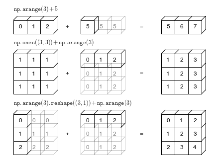

## Rules of Broadcasting

Broadcasting follows a strict set of rules to determine the interaction between the two arrays:

- Rule 1: If the two arrays differ in their number of dimensions, the shape of the one with fewer dimensions is *padded* with ones on its leading left side.
- Rule 2: If the shape of the two arrays does not match in any dimension, the array with shape equal to 1 in that dimensions is stretched to match the other shape.
- Rule 3: If in any dimension the sizes disagree and neither is equal to 1, an error is raised.

### Broadcasting example 1

Let’s look at adding a two-dimensional array to a one-dimensional array:

```python
M = np.ones((2, 3))
a = np.arange(3)

M + a
```

### Broadcasting example 2

Let’s take an example where both arrays need to be broadcast:

```python
a = np.arange(3).reshape((3, 1))
a

b = np.arange(3)
b

a + b
```

### Broadcasting example 3

Now let’s take a look at an example in which the two arrays are not compatible:

```python
M = np.ones((3, 2))
M

a = np.arange(3)
a

M + a
```

To make this work, we need to reshape the data.

```python
a[:, np.newaxis].shape

M + a[:, np.newaxis].shape
```

## Broadcasting in Practice

Here we look at a couple examples of where broadcasting is useful.

### Centering an array

Imagine you have a $10 \times 3$ array:

```python
x = np.random.random((10, 3))
x
```

We can compute the mean of each feature using the `mean` aggregate across the first dimension:

```python
xmean = x.mean(0)
xmean
```

Now we subtract the mean to center the array.

```python
x_centered = x - xmean
x_centered
```

```python
x_centered.mean(0)
```

### Plotting a two-dimensional function

If we want to define a function $z = f(x, y)$, broadcasting can be used to compute the function across the grid:

```python
# x and y have 50 steps from 0 to 5
x = np.linspace(0, 5, 50)
x

y = np.linspace(0, 5, 50)[:, np.newaxis]
y

z = np.sin(x) ** 10 + np.cos(10 + y * x) * np.cos(x)

plt.imshow(z, origin='lower', extent=[0, 5, 0, 5],
           cmap='viridis')
plt.colorbar();
plt.show()
plt.clf()
```

# Comparisons, Masks, and Boolean Logic

Masking comes up when you want to extract, modify, count, or otherwise manipulate values in an array based on some criterion.

## Example: Counting Rainy Days

Imagine you have data on the amount of precipitation each day for a year in a given city. We’ll load the daily rainfall stats for the city of Seattle in 2014 using Pandas:

```python
import numpy as np
import pandas as pd

rainfall = pd.read_csv("https://raw.githubusercontent.com/jakevdp/PythonDataScienceHandbook/master/notebooks/data/Seattle2014.csv")["PRCP"].values

inches = rainfall / 254.0
inches.shape
```

The array contains 365 values. Let’s look at a histogram of rainy days.

```python
import matplotlib.pyplot as plt
import seaborn; seaborn.set()

plt.hist(inches, 40);
plt.show()
plt.clf()
```

Most of the days in Seattle had zero rainfall. But there are other questions to answer: how many rainy days were there in the year? What is the average precipitation on those rainy days? How many days were there with more than half an inch of rain?

### Digging into the data

The best way to investigate these questions is with Python’s UFuncs.

## Comparison Operators as ufuncs

In addition to addition, subtraction, multiplication, and division, NumPy also implements comparison operators such as `<` and `>` greater than.

```python
x = np.array([1, 2, 3, 4, 5])
x

x < 3
x > 3
x <= 3
x >= 3
x != 3
x == 3
```

We can also do an element-wise comparison of two arrays and include compound expressions:

```python
(2 * x) == (x ** 2)
```

Here is a table of comparison operators and their equivalent ufuncs:

| Operator | Equivalent ufunc | Operator | Equivalent ufunc |
| --- | --- | --- | --- |
| `==` | `np.equal` | `!=` | `np.not_equal` |
| `<` | `np.less` | `<=` | `np.less_equal` |
| `>` | `np.greater` | `>=` | `np.greater_equal` |

## Working with Boolean Arrays

There are a host of useful operations you can do with Boolean arrays.

```python
rng = np.random.RandomState(0)
x = rng.randint(10, size=(3, 4))
x
```

### Counting entries

To count the number of `True` entries in a Boolean array, `np.count_nonzero` is useful:

```python
# how many values less than 6?
np.count_nonzero(x < 6)
```

Another way to get at this information is to use `np.sum`:

```python
np.sum(x < 6)
```

```python
# how many values less than 6 in each row?
np.sum(x < 6, axis = 1)
```

If we’re interested in quickly checking whether any or all the values are true, we can use `np.any` or `np.all`.

```python
# are there any values greater than 8?
np.any(x > 8)

# are there any values less than zero?
np.any(x < 0)

# are all valyes less than 10?
np.all(x < 10)

# are all values equal to 6?
np.all(x == 6)
```

These functions can also be executed along particular axes.

### Boolean operators

```python
np.sum((inches > 0.5) & (inches < 1))
```

So there are 29 days with rainfall between 0.5 and 1 inch.

Here are some other examples:

```python
print("Number days without rain:      ", np.sum(inches == 0))
print("Number days with rain:         ", np.sum(inches != 0))
print("Days with more than 0.5 inches:", np.sum(inches > 0.5))
print("Rainy days with < 0.2 inches  :", np.sum((inches > 0) &
                                                (inches < 0.2)))
```

## Boolean Array as Masks

Suppose we want to find all values in the array that are less than 5:

```python
x
```

We can use a boolean condition like this:

```python
x < 5
```

To select these values from the array, we can index on this boolean array; this is known as a *masking* operation.

```python
x[x < 5]
```

With this, we can then operate on these values as we wish. For example:

```python
# construct a mask of all rainy days
rainy = (inches > 0)

# construct a mask of all summer days (June 21st is the 172nd day)
days = np.arange(365)
summer = (days > 172) & (days < 262)

print("Median precip on rainy days in 2014 (inches):   ",
      np.median(inches[rainy]))
print("Median precip on summer days in 2014 (inches):  ",
      np.median(inches[summer]))
print("Maximum precip on summer days in 2014 (inches): ",
      np.max(inches[summer]))
print("Median precip on non-summer rainy days (inches):",
      np.median(inches[rainy & ~summer]))
```

# Fancy Indexing

Fancy indexing is like the simple indexing we’ve already seen, but we pass arrays of indices in place of single scalars. This allows us to quickly access and modify complicated subsets of an array’s values.

## Exploring Fancy Indexing

Fancy indexing means passing an array of indices to access multiple array elements at once.

```python
import numpy as np
rand = np.random.RandomState(42)

x = rand.randint(100, size = 10)
print(x)
```

Suppose we want to access three different elements. We could do it like this:

```python
[x[3], x[7], x[2]]
```

```python
ind = [3, 7, 4]
x[ind]
```

When using fancy indexing, the shape of the result reflects the shape of the *index arrays* rather than the shape of the *array being indexed*:

```python
ind = np.array([[3, 7], [4, 5]])
ind

x[ind]
```

Fancy indexing also works in multiple dimensions:

```python
x = np.arange(12).reshape((3, 4))
x
```

Like with standard indexing, the first index refers to the row, and the second to the column:

```python
row = np.array([0, 1, 2])
row

col = np.array([2, 1, 3])
x[row, col]
```

## Combined Indexing

Fancy indexing can be combined with the other indexing schemes we’ve seen:

```python
print(x)
```

We can combine fancy and simple indices:

```python
x[2, [2, 0, 1]]
```

We can also combine fancy indexing with slicing:

```python
x[1:, [2, 0, 1]]
```

And we can combine fancy indexing with masking:

```python
mask = np.array([1, 0, 1, 0], dtype = bool)
x[row[:, np.newaxis], mask]
```

## Example: Selecting Random Points

A common use of fancy indexing is selecting subsets ot rows from a matrix. For example, we might have an $N$ by $D$ matrix representing $N$ points in $D$ dimensions, such as the following points drawn from a two-dimensional normal distribution:

```python
mean = [0, 0]
cov = [[1, 2], [2, 5]]
x = rand.multivariate_normal(mean, cov, 100)
x.shape
```

We can visualize these points as a scatter-plot:

```python
import matplotlib.pyplot as plt
import seaborn; seaborn.set()

plt.scatter(x[:, 0], x[:, 1])
plt.show()
plt.clf()
```

Let’s use fancy indexing to select 20 random points.

```python
indices = np.random.choice(x.shape[0], 20, replace = False)
indices

selection = x[indices]
selection.shape
```

Now we can see which points were selected:

```python
plt.scatter(x[:, 0], x[:, 1], alpha = 0.3)
plt.scatter(selection[:, 0], selection[:, 1], facecolor = "none", s = 200)
plt.show()
plt.clf()
```

## Modifying Values with Fancy Indexing

Imagine we have an array of indices and we’d like to set the corresponding items in an array to some value:

```python
x = np.arange(10)
i = np.array([2, 1, 8, 4])
x[i] = 99
print(x)
```

We can use any assignment-type operator for this:

```python
x[i] -= 10
print(x)
```

## Example: Binning Data

You can use these tools to bin data to create a histogram.

# Sorting Arrays

A selection sort repeatedly finds the minimum value from a list, and makes swaps until the list is sorted.

```python
import numpy as np

def selection_sort(x):
    for i in range(len(x)):
        swap = i + np.argmin(x[i])
        (x[i], x[swap]) = (x[swap], x[i])
    return x

x = np.array([2, 1, 4, 3, 5])
selection_sort(x)
```

## Fast Sorting in NumPy: `np.sort` and `np.argsort`

To return a sorted version of the array without modifying the input, you can use `np.sort`:

```python
x = np.array([2, 1, 4, 3, 5])
np.sort(x)
```

If you prefer to sort the array in-place, you can instead use the `sort` method of arrays:

```python
x.sort()
x
```

A related function is `argsort`, which instead returns the *indices* of the sorted elements:

```python
x = np.array([2, 1, 4, 3, 5])
i = np.argsort(x)
print(i)
```

### Sorting along rows or columns

NumPy can sort along specific rows or columns with the `axis` argument.

```python
rand = np.random.RandomState(42)
x = rand.randint(0, 10, (4, 6))
print(x)

# sort each column of X
np.sort(x, axis = 0)

# sort each row of x
np.sort(x, axis = 1)
```

## Partial Sorts: Partitioning

Sometimes we just want to find the *k* smallest values in the array. We can do this with the `np.partition` function. `np.partition` takes an array and a number *k*; the result is a new array with the smallest *k* values to the left of the partition, and the remaining values to the right, in arbitrary order:

```python
x = np.array([7, 2, 3, 1, 6, 5, 4])
np.partition(x, 3)
```

We can also partition along other axes:

```python
x = rand.randint(0, 10, (4, 6))
np.partition(x, 2, axis = 1)
```

The result is an array where the first two slots in each row contain the smallest values from that row, with the remaining values filling the remaining slots.

## Example: k-Nearest Neighbors

Let’s use the `argsort` function to find the nearest neighbors of each point in a set.

```python
# create a random set of 10 points
x = rand.rand(10, 2)

# scatter plot
import matplotlib.pyplot as plt
import seaborn
plt.scatter(x[:, 0], x[:, 1], s = 100)
plt.show()
plt.clf()
```

Now compute the distance between each pair of points:

```python
dist_sq = np.sum((x[:, np.newaxis, :] - x[np.newaxis, :, :]) ** 2, axis = -1)
```

Let’s break down this code:

```python
# for each pair of points, compute differences in their coordinates
differences = x[:, np.newaxis, :] - x[np.newaxis, :, :]
differences.shape

# square the coordinate differences
sq_differences = differences ** 2
sq_differences.shape

# sum the coordinate differences to get the squared distance
dist_sq = sq_differences.sum(-1)
dist_sq.shape
```

Now we use `np.argsort` to sort along each row.

```python
nearest = np.argsort(dist_sq, axis = 1)
print(nearest)
```

If we only care about the nearest $k$ neighbors, all need is to partition each row so that the smallest $k + 1$ squared distances come first.

```python
k = 2
nearest_partition = np.argpartition(dist_sq, k + 1, axis = 1)
```

We can plot the points to visualize this network of neighbors.

```python
plt.scatter(x[:, 0], x[:, 1], s = 100)

k = 2

for i in range(x.shape[0]):
    for j in nearest_partition[i, :k + 1]:
        # plot a line from x[i] to x[j]
        # use some zip magic to make it happen:
        plt.plot(*zip(x[j], x[i]), color = "black")

plt.show()
plt.clf()
```

# Structured Data: NumPy’s Structured Arrays

Imagine that we have several categories of data on a number of people, and we’d like to store these values for use in a Python program. It would be possible to store these in separate arrays:

```python
name = ['Alice', 'Bob', 'Cathy', 'Doug']
age = [25, 45, 37, 19]
weight = [55.0, 85.5, 68.0, 61.5]
```

But it would be more natural to use a single structure to store all of the data. This is what structured arrays are for.

```python
x = np.zeros(4, dtype = int)
```

We can create structured arrays in a similar fashion:

```python
# use a compound data type for structured arrays
data = np.zeros(4, dtype = {"names":("name", "age", "weight"),
                            "formats":("U10", "i4", "f8")})
print(data.dtype)
```

Now we can fill this empty container array with the list of values:

```python
data['name'] = name
data['age'] = age
data['weight'] = weight
print(data)
```

Now we can refer to values either by indexing or by name:

```python
# get all names
data["name"]

# get first row of data
data[0]

# get the name from the last row
data[-1]["name"]
```

With Boolean masking, we can also do things like filter on age:

```python
# get names where age is under 30
data[data["age"] < 30]["name"]
```

## Creating Structured Arrays

Structured array data types can be specified in a number of ways. Earlier, we saw the dictionary method:

```python
np.dtype({'names':('name', 'age', 'weight'),
          'formats':('U10', 'i4', 'f8')})
```

If the names don’t matter, we can just specify the types alone in a comma-separated string:

```python
np.dtype("S10, i4, f8")
```

## More Advanced Compound Types

It is possible to define even more advanced compound types.

## RecordArrays: Structured Arrays with a Twist

NumPy also provides `np.rearray` which allows you to access fields as attributes rather than as dictionary keys.